# Explore Data: Samoa

Julie

4/18/2018

```r
## libraries
library(tidyverse)

## country focus
key <- 'sam'
rgn_name <- 'Samoa'

## filepaths
raw_prefix <- 'https://raw.githubusercontent.com/OHI-Science'
rawkey_prefix <- file.path('https://raw.githubusercontent.com/OHI-Science', key, "master")


## read in data from web (minimize how often pull from web) ----

scores_gf_csv <- read_csv(file.path(rawkey_prefix, "global2015/gapFilling/scores.csv"))
scores_csv <- read_csv(file.path(rawkey_prefix, "eez/scores.csv"))
fis_meancatch_csv <- read_csv(file.path(rawkey_prefix, "/eez/layers/fis_meancatch.csv"))
fis_b_bmsy_csv <- read_csv(file.path(rawkey_prefix, "/eez/layers/fis_b_bmsy.csv"))

## get global rgn_id
rgn_global <- read_csv(file.path(raw_prefix, 'ohirepos-log/master/rgn_global.csv')) %>%
  filter(label == rgn_name) # 152
```

## Introduction

This workshop compliments http://ohi-science.org/country-opportunities-training.

## Data for Samoa

### Habitats

### Fisheries

The Fisheries (FIS) subgoal measures wildcaught fish catch within your EEZ. Our models need catch for at least 10 years (20 is better). Ideally, we would also have status (at least B/BMSY, bonus is F/FMSY).

Data are from the [Sea Around Us Project](http://www.seaaroundus.org).

We can look at an interactive visualization of [fish caught in Samoa’s EEZ](http://www.seaaroundus.org/data/#/eez/882?chart=catch-chart&dimension=taxon&measure=tonnage&limit=20):

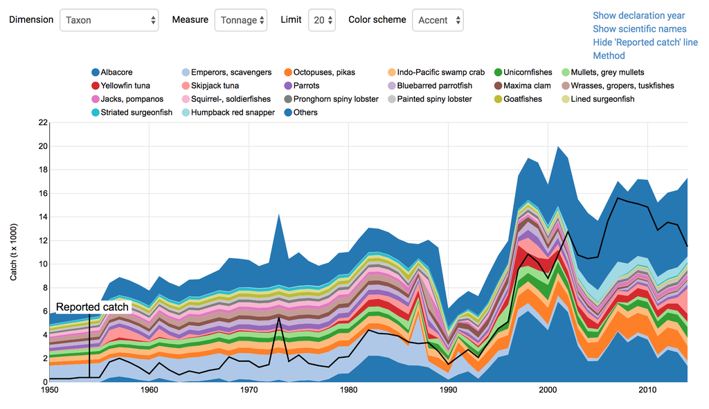

We can also look at an interactive visualization of [Samoa fishing around the world](http://www.seaaroundus.org/data/#/spatial-catch?entities=192) (mostly high seas and agreements with other countries):

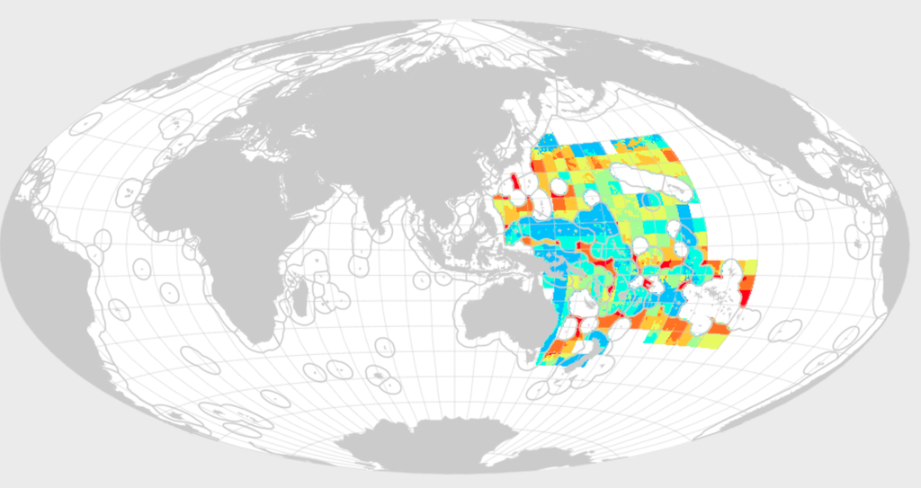

#### Workshop discussion:

- remove species
- improve meancatch estimates, especially for catch that is grouped instead of by species.

**Remove species**

Let’s look at the species list that is include in Samoa’s FIS model.

**Questions about local data**

By “local data”, we mean your data in Samoa. We want to talk about how it differs from the global data we have in our models for Samoa.

What fisheries data do you have? The criteria we need is:

- species list
- catch by species: only what is fished within Samoa’s EEZ
- years: at least 10 years of data (preferably 20)

Depending on the format, we’d be able to update data for those species, recalculate either with only those species, or mix-and-match SAUP and local data.

*Note*: we cannot add new species in this workshop. That will take more attention and time than we can give. We would need to add meancatch values, as well as matching b_bmsy estimates.

Let’s look at the list of species that are represented in the FIS model (this is the [fis_meancatch](https://raw.githubusercontent.com/OHI-Science/sam/master//eez/layers/fis_meancatch.csv) layer:

| stock_id_taxonkey |
| --- |
| Marine_fishes_not_identified-77_100039 |
| Miscellaneous_aquatic_invertebrates-77_100077 |
| Marine_pelagic_fishes_not_identified-77_100339 |
| Mollusca-77_190195 |
| Elasmobranchii-77_200004 |
| Scombroidea-77_300036 |
| Decapoda-77_390013 |
| Muraenidae-77_400056 |
| Holocentridae-77_400243 |
| Serranidae-77_400289 |
| Carangidae-77_400314 |
| Lutjanidae-77_400323 |
| Lethrinidae-77_400328 |
| Mullidae-77_400332 |
| Mugilidae-77_400359 |
| Labridae-77_400362 |
| Acanthuridae-77_400412 |
| Siganidae-77_400413 |
| Scombridae-77_400416 |
| Istiophoridae-77_400419 |
| Scarus-77_500242 |
| Sphyraena-77_500372 |
| Gymnothorax-77_500384 |
| Naso-77_500480 |
| Isurus-77_500638 |
| Alopias-77_500639 |
| Etelis-77_501116 |
| Pristipomoides-77_502124 |
| Octopus-77_590013 |
| Coryphaena_hippurus-77_600006 |
| Chanos_chanos-77_600080 |
| Aphareus_rutilans-77_600083 |
| Aprion_virescens-77_600084 |
| Acanthocybium_solandri-77_600089 |
| Alepisaurus_ferox-77_600099 |
| Katsuwonus_pelamis-77_600107 |
| Thunnus_alalunga-77_600142 |
| Thunnus_albacares-77_600143 |
| Thunnus_obesus-77_600146 |
| Lutjanus_kasmira-77_600156 |
| Istiompax_indica-77_600217 |
| Makaira_mazara-77_600218 |
| Kajikia_audax-77_600223 |
| Xiphias_gladius-77_600226 |
| Lutjanus_gibbus-77_600265 |
| Selar_crumenophthalmus-77_600387 |
| Elagatis_bipinnulata-77_600412 |
| Carcharhinus_falciformis-77_600868 |
| Carcharhinus_galapagensis-77_600870 |
| Carcharhinus_longimanus-77_600875 |
| Carcharhinus_melanopterus-77_600877 |
| Prionace_glauca-77_600898 |
| Lepidocybium_flavobrunneum-77_601042 |
| Ruvettus_pretiosus-77_601044 |
| Lampris_guttatus-77_601072 |
| Sphyraena_barracuda-77_601235 |
| Acanthurus_lineatus-77_601258 |
| Ctenochaetus_striatus-77_601262 |
| Naso_unicornis-77_601265 |
| Lethrinus_olivaceus-77_601864 |
| Alopias_superciliosus-77_602534 |
| Tetrapturus_angustirostris-77_603915 |
| Variola_louti-77_605354 |
| Scarus_ghobban-77_605548 |
| Thunnus_orientalis-77_614290 |
| Tridacna_squamosa-77_690134 |
| Scylla_serrata-77_690190 |
| Tridacna_maxima-77_690673 |
| Panulirus_penicillatus-77_690801 |
| Panulirus_versicolor-77_690802 |
| Parribacus_caledonicus-77_690882 |
| Echinodermata-77_190277 |
| Sphyrna-77_500693 |

```r
## these values don't change through time
#ggplot(data = fis_meancatch, aes(x = year, y = mean_catch)) +
#         geom_line(aes(color = stock_id_taxonkey)) +
#  theme(legend.position="none")
```

| rgn_id | stock_id_taxonkey | year | mean_catch |
| --- | --- | --- | --- |
| 152 | Xiphias_gladius-77_600226 | 2001 | 55.67419 |
| 152 | Xiphias_gladius-77_600226 | 2002 | 55.67419 |
| 152 | Xiphias_gladius-77_600226 | 2003 | 55.67419 |
| 152 | Xiphias_gladius-77_600226 | 2004 | 55.67419 |
| 152 | Xiphias_gladius-77_600226 | 2005 | 55.67419 |
| 152 | Xiphias_gladius-77_600226 | 2006 | 55.67419 |
| 152 | Xiphias_gladius-77_600226 | 2007 | 55.67419 |
| 152 | Xiphias_gladius-77_600226 | 2008 | 55.67419 |
| 152 | Xiphias_gladius-77_600226 | 2009 | 55.67419 |
| 152 | Xiphias_gladius-77_600226 | 2010 | 55.67419 |
| 152 | Xiphias_gladius-77_600226 | 2011 | 55.67419 |
| 152 | Xiphias_gladius-77_600226 | 2012 | 55.67419 |
| 152 | Xiphias_gladius-77_600226 | 2013 | 55.67419 |
| 152 | Xiphias_gladius-77_600226 | 2014 | 55.67419 |

Now let’s look at b_bmsy:

| stock_id |
| --- |
| Coryphaena_hippurus-77 |
| Chanos_chanos-77 |
| Acanthocybium_solandri-77 |
| Katsuwonus_pelamis-77 |
| Thunnus_alalunga-77 |
| Thunnus_albacares-77 |
| Thunnus_obesus-77 |
| Kajikia_audax-77 |
| Xiphias_gladius-77 |
| Selar_crumenophthalmus-77 |
| Carcharhinus_falciformis-77 |
| Carcharhinus_longimanus-77 |
| Prionace_glauca-77 |
| Thunnus_orientalis-77 |

and a single species (*Xiphias_gladius-77*)

| rgn_id | stock_id | year | bbmsy |
| --- | --- | --- | --- |
| 152 | Xiphias_gladius-77 | 2001 | 1.468611 |
| 152 | Xiphias_gladius-77 | 2002 | 1.413867 |
| 152 | Xiphias_gladius-77 | 2003 | 1.344380 |
| 152 | Xiphias_gladius-77 | 2004 | 1.270593 |
| 152 | Xiphias_gladius-77 | 2005 | 1.225540 |
| 152 | Xiphias_gladius-77 | 2006 | 1.209736 |
| 152 | Xiphias_gladius-77 | 2007 | 1.213713 |
| 152 | Xiphias_gladius-77 | 2008 | 1.239015 |
| 152 | Xiphias_gladius-77 | 2009 | 1.276003 |
| 152 | Xiphias_gladius-77 | 2010 | 1.287259 |
| 152 | Xiphias_gladius-77 | 2011 | 1.286469 |
| 152 | Xiphias_gladius-77 | 2012 | 1.261431 |
| 152 | Xiphias_gladius-77 | 2013 | 1.220107 |
| 152 | Xiphias_gladius-77 | 2014 | 1.159402 |

These species from f_b_bmsy.csv:

### MAR

from mar_sustainability_score

152,2012,“Bear paw clam_507”,0.811764706 152,2012,“Elongate giant clam_508”,0.811764706 152,2012,“Fluted giant clam_509”,0.811764706 152,2012,“Giant clam_510”,0.811764706 152,2012,“Smooth giant clam_511”,0.811764706

### Iconic Species

## Gapfilling in Samoa

Let’s have a look at the percent gapfilling by goal. This shows that there are several goals that have very little gapfilling in terms of the data involved:

AO, SPP, LSP, SP, ICO, and NP

| goal | percent_gapfilled |
| --- | --- |
| AO | 0.04 |
| SPP | 0.06 |
| LSP | 0.07 |
| SP | 0.10 |
| ICO | 0.12 |
| NP | 1.80 |
| CW | 10.59 |
| Index | 32.61 |
| BD | 41.74 |
| CP | 42.81 |
| CS | 45.93 |
| MAR | 46.04 |
| FP | 58.74 |
| FIS | 58.74 |
| HAB | 83.42 |
| TR | 91.77 |

We can actually compare the percent gapfilling by goal to the scores per goal. It looks like HAB had the highest score but also some of the highest percentage of gapfilling.

| goal | score |
| --- | --- |
| AO | 69.12 |
| BD | 92.00 |
| CP | 90.92 |
| CS | 85.51 |
| CW | 82.78 |
| ECO | 76.41 |
| FIS | 61.50 |
| FP | 61.50 |
| HAB | 92.76 |
| ICO | 64.00 |
| LE | 39.88 |
| LIV | 3.34 |
| LSP | 1.02 |
| MAR | 0.00 |
| NP | 48.42 |
| SP | 32.51 |
| SPP | 91.24 |
| TR | 65.19 |

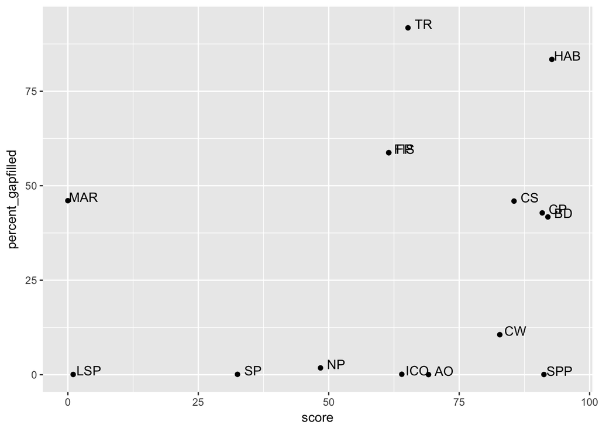

### Discussion

Priorities for goals, based on gapfilled data alone: TR, HAB

### Gapfilling Breakdown by goals

https://raw.githubusercontent.com/OHI-Science/ohi-global/draft/eez/temp/FIS_summary_gf.csv

### Breakdown by pressures/resilience

[pressure_matrix_CP_gapfill](https://github.com/OHI-Science/ohi-global/blob/draft/global2015/gapFilling/pressure_matrix_CP.csv)

```r
y <- read_csv(file.path(rawkey_prefix, "global2015/gapFilling/pressure_matrix_CP.csv")) %>%
  filter(X1 == rgn_global$rgn_id)
```

## Data

### HAB vs CP vs CS

### TR